# Climate and Its Effect on the Skiing and Hiking Industry in Zürich, Switzerland

Emily Tomz

12/20/2019

The dataset used for this blog post comes from the National Oceanic and Atmospheric Administration’s collection of climate stations in Switzerland. This particular station is located in Zürich, Switzerland, with the proper station name of ‘ZUERICH FLUNTERN, SZ’. It lies at an elevation of 555m, with 100% data coverage ranging from January 1, 1901 until September 9, 2019.

The dataset includes precipitation, snow, maximum temperature, minimum temperature, and average temperature data. This blog consideres all aspects of the dataset, as well as its implications regarding the skiing and hiking industries in Switzerland.

A city located in northern Switzerland, Zürich is a unique masterpiece of the world. Situated next to a gorgeous lake with magificent Swiss Alps in view, Zürich is home to a substantial number of environmental lovers, groups, and institutions. And, with its proixmity to the mountains, it is also a key location for skiing and hiking, two of the largest industries in the country.

According to the Swiss Tourism Federation, in 2018 tourism accounted for 44.7 billion Swiss Francs (45.48 billion US dollars) in revenue, making it one of the largest export industries in Switzerland at 4.4% of the country’s export revenue.

One of the most prominent activities in the country, and in Zürich in particular, is skiing. After a dip in Skier-days in Switzerland, it is again on the first in 2018, benefiting the economy. In winter, exist 551 total offers of winter hiking, snowshoe walking, cross-country skiing, and sledging. Switzerland offers 154 ski schools across the country, the success of which depends on the number of visitors to the slopes.

Hiking is another common activity, with 294 local routes across the country in addition to the 224 routes for mountain biking. In Zürich in particular, there are almost 3,000 km of walks. According to the federation, hiking is the most popular leisure and sporting activity in Switzerland for people of all ages, with its popularity rising over the last decade. Considering the economy, hiking expendatures account for approximately 2.8 billion Swiss Francs in revenue each year, due to travel, meals, equipment, overnight accomodation, and other modes of spending.

However, hiking and skiing both rely on specific climates for them to be appropriate activities. Skiing requires snow, and hiking requires (for most people) decent weather. Thus, it is crucial to consider climate trends in Zürich in order to predict what may happen to the city’s and country’s skiing and hiking industries in the future as climate change becomes an increasingly serious issue.

## Maximum Temperature over Time

First, we consider maximum temperature over time. Data has shown that with climate change, temperature is increasing on average worldwide, especially after the start of the Industrial Revolution in the mid 1700s. Plotting maximum daily temperature over time, we see if this trend appears in Zürich, Switzerland.

```
##
## Call:
## lm(formula = TMAX ~ NewDate, data = climate_data)
##
## Residuals:
##      Min       1Q   Median       3Q      Max
## -31.0728  -7.2731   0.1583   7.2967  23.6831
##
## Coefficients:
##               Estimate Std. Error t value Pr(>|t|)
## (Intercept)  1.390e+01  4.519e-02 307.609  < 2e-16 ***
## NewDate     -1.416e-05  3.474e-06  -4.078 4.56e-05 ***
## ---
## Signif. codes:  0 '***' 0.001 '**' 0.01 '*' 0.05 '.' 0.1 ' ' 1
##
## Residual standard error: 9.068 on 43402 degrees of freedom
##   (15 observations deleted due to missingness)
## Multiple R-squared:  0.0003829,  Adjusted R-squared:  0.0003599
## F-statistic: 16.63 on 1 and 43402 DF,  p-value: 4.558e-05
```

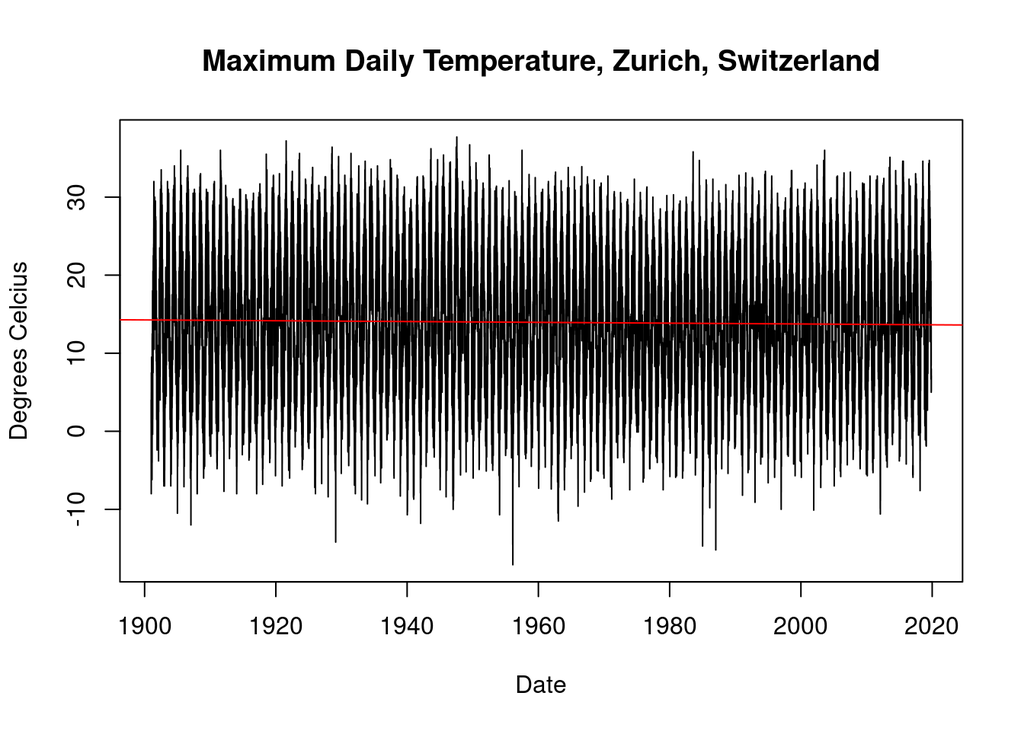

The plot of the maixmum daily temperature at the Zürich climate station over the last century appears all over the place, but the red trend line appears relatively stagnant. The constant upper and lower spikes that are visible throughout the graph highlight the variation in temperature that occurs day by day throughout the course of each year, decade, and the century as a whole.

Statistically, the slope of the trend line of maximum daily temperature over time is represented as such:

y = 13.90 - 1.416 * 10^(-5)

While this trend does not agree with the studies that have shown that temperature is rising on average across the world, it is still relevant to consider.

## Maximum Monthly Means

In order to visually simplify the dataset, below is a plot of maximum monthly average temperature over time. The plot is less dense, but it still represents the same image as the plot of maximum monthly daily temperature over time, with the same trend line depicted in red.

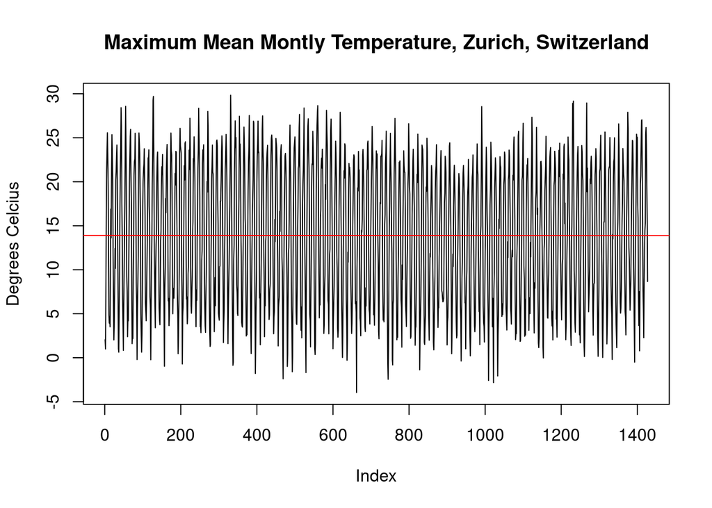

## Maximum Temperature over Time: By Month

As shown in the daily and monthly temperature graphs, there is a lot of data and a lot of variation within that data. Temperatures vary greatly over the 365 (+1) days in every year, creating the striking spikes in the temperature plots. Some months are warmer, some months are colder, and differences between monthly and daily temperatures can range greatly. Thus, it is crucial to consider temperature trends not only by day and month over the course of the last century, but to actually split the data up by month.

A particular application of the importance of splitting up the data by month arises when considering the skiing and hiking industries in Switzerland. Known for its grandeur and strikingly beautiful Swis alps alongside lakes and hillsides, Zürich is a place of adventure and outdoor excursion.

Ski season typically occurs within the months of December - March, while hiking season typically occurs within the months of May - September. Thus, let’s look at the monthly trends in maximum temperature.

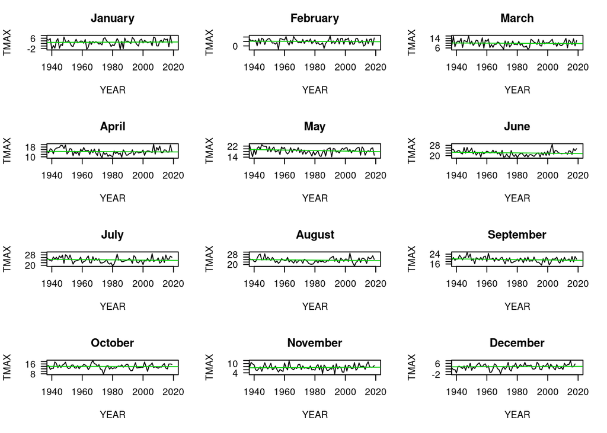

```
##
## Call:
## lm(formula = TMAX ~ YEAR, data = MonthlyTMAXMean[MonthlyTMAXMean$Month ==
##     "05", ])
##
## Residuals:
##     Min      1Q  Median      3Q     Max
## -6.5711 -1.4653  0.2538  1.7317  3.7013
##
## Coefficients:
##              Estimate Std. Error t value Pr(>|t|)
## (Intercept) 55.355770  11.108801   4.983 2.19e-06 ***
## YEAR        -0.018489   0.005667  -3.263  0.00145 **
## ---
## Signif. codes:  0 '***' 0.001 '**' 0.01 '*' 0.05 '.' 0.1 ' ' 1
##
## Residual standard error: 2.124 on 117 degrees of freedom
## Multiple R-squared:  0.08339,    Adjusted R-squared:  0.07556
## F-statistic: 10.64 on 1 and 117 DF,  p-value: 0.001447
```

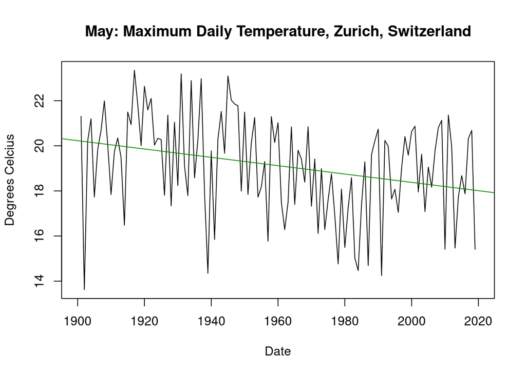

Considering the month of May in particular, we see a statistically significant (p-value = 0.00145) slope of -0.018489 degrees celcius per year. Over the course of a century this translates to a decrease of 1.85 degrees Celcius. Although this appears to be minimal, it may have grand effects on the ecosystems of Zürich, including its physical features such as alps and lakes.

## Minimum Daily Temperatures over Time

Studies have shown that as the worldwide average temparature increasing, ski season length will degrease. Interestingly, however, this data shows a slight decrease in maximum temperature over time. Maximum temperature does not dictate the entire story, though, so it is important to also take a look at the trend of minimum temperature over time.

```
##
## Call:
## lm(formula = TMIN ~ NewDate, data = climate_data)
##
## Residuals:
##      Min       1Q   Median       3Q      Max
## -29.0951  -5.0350   0.1527   5.4388  16.1748
##
## Coefficients:
##              Estimate Std. Error t value Pr(>|t|)
## (Intercept) 5.557e+00  3.299e-02  168.44   <2e-16 ***
## NewDate     4.431e-05  2.536e-06   17.47   <2e-16 ***
## ---
## Signif. codes:  0 '***' 0.001 '**' 0.01 '*' 0.05 '.' 0.1 ' ' 1
##
## Residual standard error: 6.616 on 43379 degrees of freedom
##   (38 observations deleted due to missingness)
## Multiple R-squared:  0.006988,   Adjusted R-squared:  0.006965
## F-statistic: 305.3 on 1 and 43379 DF,  p-value: < 2.2e-16
```

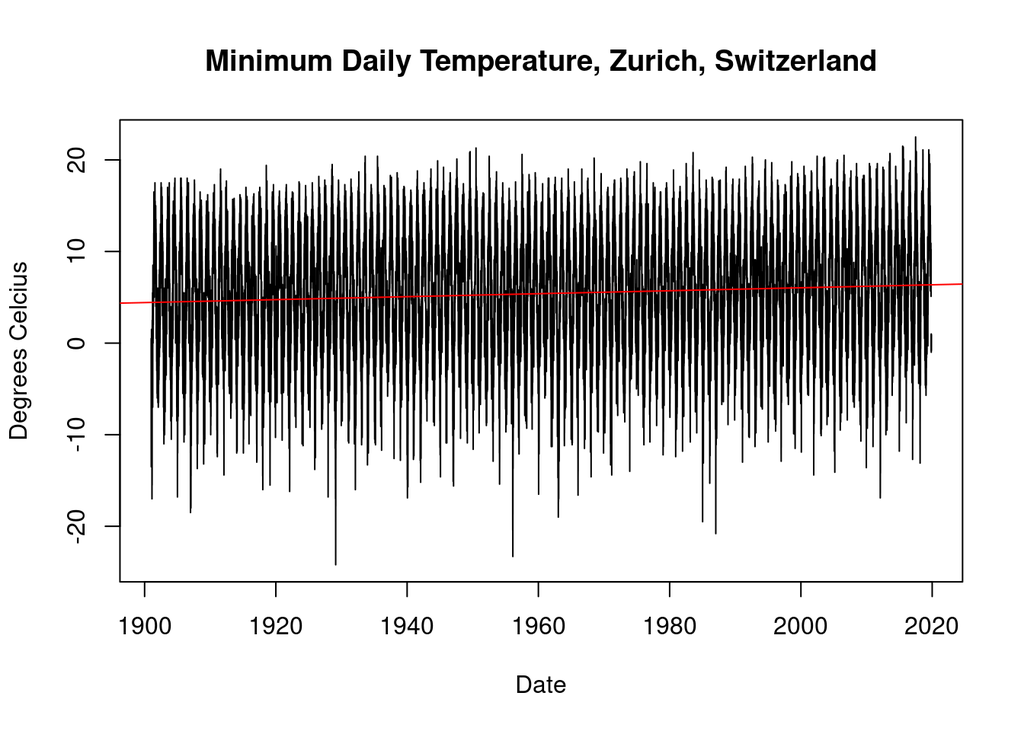

## Minimum Monthly Means

Reducing the data into a tighter plot of minimum average monthly temperature over time once again creates a more concise graph of the minimum temperature trend over time.

```
##     Month               Year                TMIN               YEAR
##  Length:1427        Length:1427        Min.   :-12.5621   Min.   :1901
##  Class :character   Class :character   1st Qu.:  0.3355   1st Qu.:1930
##  Mode  :character   Mode  :character   Median :  5.2867   Median :1960
##                                        Mean   :  5.3627   Mean   :1960
##                                        3rd Qu.: 10.8733   3rd Qu.:1990
##                                        Max.   : 17.0833   Max.   :2019
##      MONTH
##  Min.   : 1.000
##  1st Qu.: 3.500
##  Median : 6.000
##  Mean   : 6.496
##  3rd Qu.: 9.000
##  Max.   :12.000
```

[output not shown]

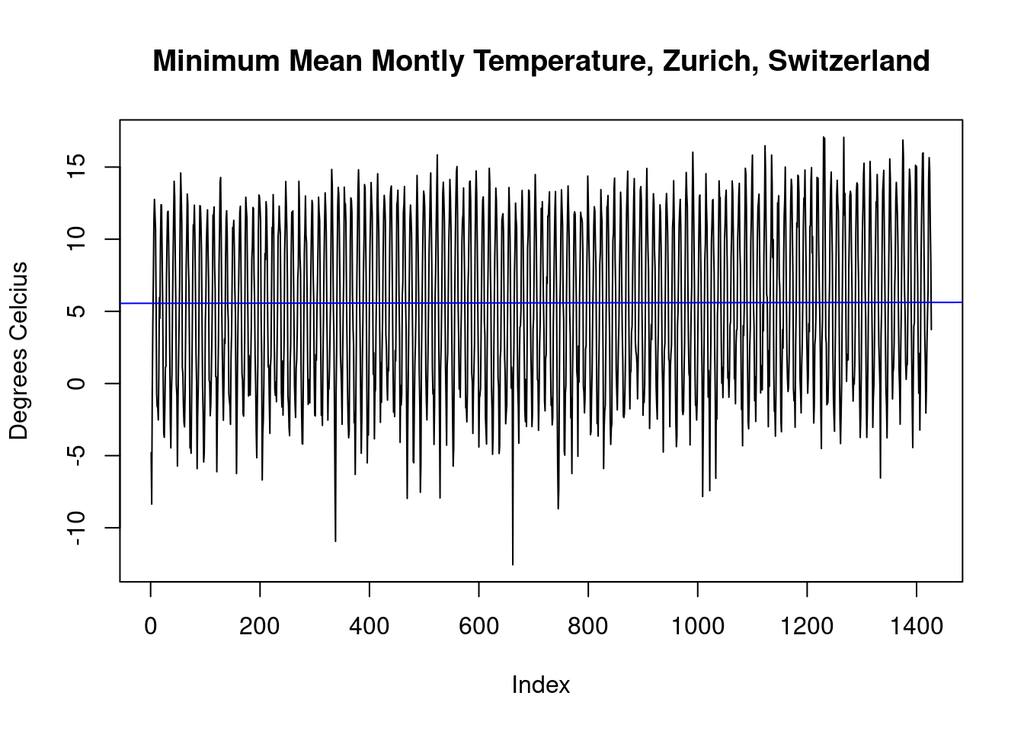

The finding that the trend line is significant, and therefore that minimum temperature increases over time, is even more interesting when paired with the finding that maximum temperature decreases over time. In Zürich, although the maximum and minimum temperatures are’t both rising, as climate data has shown to be the average case across the planet, the gap between the maximum and minimum temperatures is decreasing. The winter is warmer and the summer is colder, creating minimal season extremes.

## Minimum Temperature over Time: By Month

Once again, due to month-by-month variation, it is useful to view the trends of each month individually as opposed to on a graph where they are all clumped together.

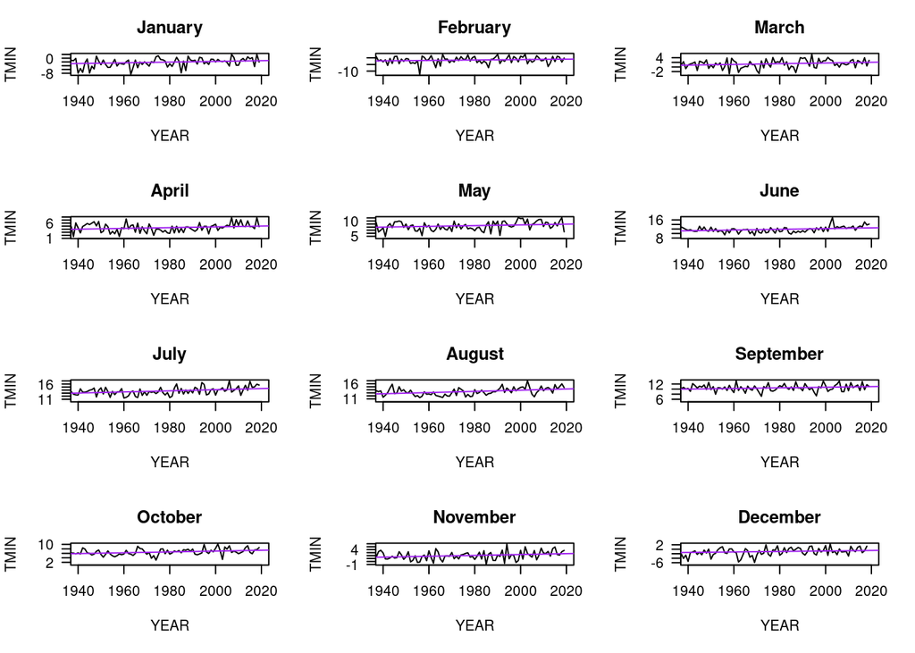

One of the months with the most extreme positive slope is January, a month in the middle of the prime skiing season. Below is a graph that takes a closer look at the temperature trend of January.

```
##
## Call:
## lm(formula = TMIN ~ YEAR, data = MonthlyTMINMean[MonthlyTMINMean$Month ==
##     "01", ])
##
## Residuals:
##     Min      1Q  Median      3Q     Max
## -6.2718 -1.2488  0.2589  1.4477  4.7497
##
## Coefficients:
##               Estimate Std. Error t value Pr(>|t|)
## (Intercept) -39.295145  11.631045  -3.378 0.000991 ***
## YEAR          0.018792   0.005933   3.167 0.001963 **
## ---
## Signif. codes:  0 '***' 0.001 '**' 0.01 '*' 0.05 '.' 0.1 ' ' 1
##
## Residual standard error: 2.223 on 117 degrees of freedom
## Multiple R-squared:  0.07897,    Adjusted R-squared:  0.0711
## F-statistic: 10.03 on 1 and 117 DF,  p-value: 0.001963
```

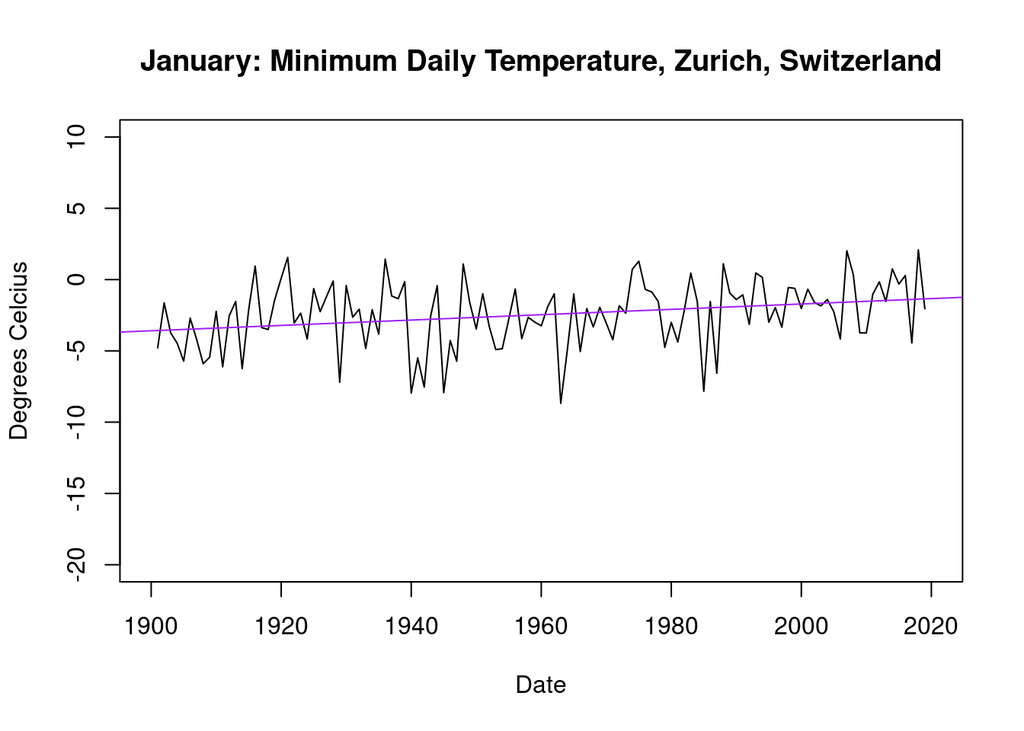

With a slope of 0.018792 and a significant p-value of 0.001963, we are once again able to reject the null hypothesis and conclude that the increase in minimum temperature over time for January does not occur by chance. It is in fact affected by time. Looking at the slope in more detail, 0.018792 degrees Celcius is a relatively large average increase in temperature per year. This corresponds to an increase in 1.8792 degrees celcius over the course of a century, which is exactly in line with the global average temperature increase trends. Studies have attributed this 1.8 degree increase in temperature to a reduction in snow among other changes within ecosystems.

## Table of Significant Temperatures

The following table depicts monthly maximum and miniumum temperatures, as well as their significance level. The significance levels range from most to least significant based on the symbols of " * * * “,” * * “,” * “, and”NS".

```
## % latex table generated in R 3.6.0 by xtable 1.8-4 package
## % Fri Dec 20 22:31:29 2019
## \begin{table}[ht]
## \centering
## \begin{tabular}{rlllll}
##   \hline
##  & Month & Slope TMIN & R\verb|^|2 & Slope TMAX & R\verb|^|2.1 \\
##   \hline
## 1 & January & 0.0188 ** & 0.079 & 0.0033 NS & 0.002 \\
##   2 & February & 0.0159 * & 0.044 & -0.0066 NS & 0.006 \\
##   3 & March & 0.0153 *** & 0.094 & -0.0052 NS & 0.006 \\
##   4 & April & 0.0127 *** & 0.102 & -0.0051 NS & 0.006 \\
##   5 & May & 0.0119 ** & 0.084 & -0.0185 ** & 0.083 \\
##   6 & June & 0.016 *** & 0.171 & -0.0115 * & 0.037 \\
##   7 & July & 0.0185 *** & 0.24 & -0.0098 NS & 0.025 \\
##   8 & August & 0.0198 *** & 0.296 & -0.01 NS & 0.031 \\
##   9 & September & 0.0121 ** & 0.084 & -0.0143 * & 0.052 \\
##   10 & October & 0.0187 *** & 0.191 & -0.0022 NS & 0.002 \\
##   11 & November & 0.0147 *** & 0.119 & 0.0041 NS & 0.006 \\
##   12 & December & 0.0111 * & 0.045 & 0.0035 NS & 0.004 \\
##    \hline
## \end{tabular}
## \end{table}
```

Interestingly, all of the TMIN slopes are statistically significant, while only three of the TMAX slopes are, and more minimally so. Among the TMIN slopes, the most significant occur in March, April, June, July, August, October, and November. There is no obvious reason why this is the case, although one possibility is that it may have been more variable to collect data during December, January, and February when there may have been more extreme weather events. The three months that have both significant TMIN and significant TMAX slopes are May, June, and September, although they do not necessarily have the lowest R^2 value, which represents the amount of variability in the data.

## Precipitation: Departure from Mean

Precipitation is another signficiant piece of data that demands attention, especially when considering snowfall in Zürich, Switzerland.

```
##
## Call:
## lm(formula = ppt ~ Date, data = PPT)
##
## Residuals:
##      Min       1Q   Median       3Q      Max
## -101.288  -38.678   -8.202   30.706  201.976
##
## Coefficients:
##             Estimate Std. Error t value Pr(>|t|)
## (Intercept) -87.7152    51.3561  -1.708 0.087858 .
## Date          1.0528     0.3023   3.483 0.000512 ***
## ---
## Signif. codes:  0 '***' 0.001 '**' 0.01 '*' 0.05 '.' 0.1 ' ' 1
##
## Residual standard error: 51.13 on 1425 degrees of freedom
## Multiple R-squared:  0.00844,    Adjusted R-squared:  0.007744
## F-statistic: 12.13 on 1 and 1425 DF,  p-value: 0.0005115
```

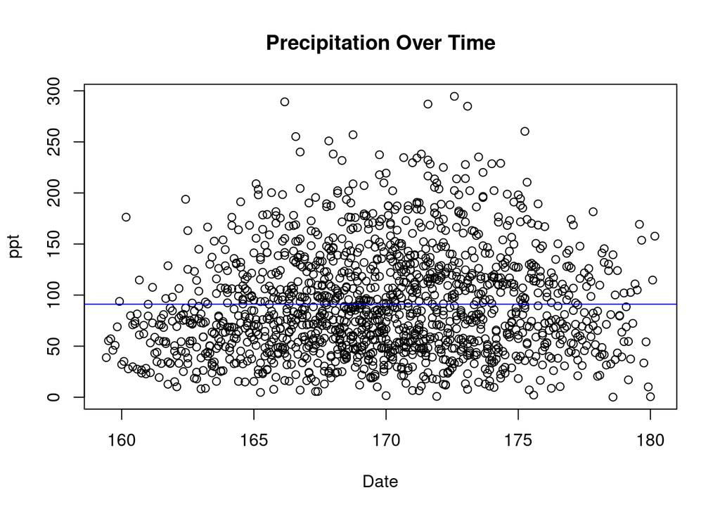

The spread of the precipitation data is relatively even above and below the trend line, so while it is spread out, it doesn’t necessarily reveal much about any trend in precipitation over time. However, the statistics of the trend line reveal something different. With a p-value of 0.000512, the slope is statistically significant. That is, the data shows that the non-zero slope of 1.0528 does not simply occur by chance. In fact, we can now claim that precipitation is increasing over time. Although it may be a slow increase, it is there, and it is affected by time.

## Plot GDP over time

Plotting GDP over time will allow us to see if there is any trend in GDP that mirrors or opposes the trends found in climate.

```
##
## Call:
## lm(formula = GDP ~ NewDate, data = gdp_data)
##
## Residuals:
##     Min      1Q  Median      3Q     Max
## -8744.4 -3064.9   593.1  2597.7  8167.6
##
## Coefficients:
##              Estimate Std. Error t value Pr(>|t|)
## (Intercept) 6.118e+04  8.614e+02   71.03   <2e-16 ***
## NewDate     6.145e+00  7.397e-02   83.08   <2e-16 ***
## ---
## Signif. codes:  0 '***' 0.001 '**' 0.01 '*' 0.05 '.' 0.1 ' ' 1
##
## Residual standard error: 3909 on 157 degrees of freedom
## Multiple R-squared:  0.9778, Adjusted R-squared:  0.9776
## F-statistic:  6902 on 1 and 157 DF,  p-value: < 2.2e-16
```

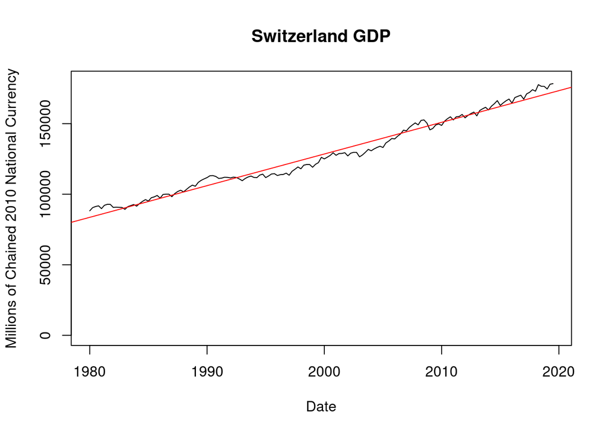

The plot of GDP over time in Switzerland shows a largly statistically significant slope of 6.145. This striking increase in GDP over the years opposes the expected trend given the rise in temperature. It would be expected that as temperature rises and ski season and its subsequent revenue decrease, the economy would fall with it.

Thus, it could be that the Switzerland economy does not depend enough on the ski industry to be hurt significantly by it as temperature rises. However, it could also be that the economy has simply not been affected yet. In the future it could. It is still a possibility, so it is something that residents, tourists, and policy-makers need to keep in mind. This relevance of this is depicted once again through a graph on snowfall over the last century.

## Snow

The plot below depicts the change in snowfall over the course of the last century. Again, while the graph doesn’t seem to show much on the surface, the summary of the linear regression actually provides a negative slope that is statistically significant. That is, snow amount depends on time, and it is decreasing with time. Thus, the reduced ski season is a relevant issue that demands consideration in Zürich and other cities in Switzerland.

```
##
## Call:
## lm(formula = SNWD ~ NewDate, data = climate_data[climate_data$SNWD !=
##     "0.0", ])
##
## Residuals:
##    Min     1Q Median     3Q    Max
## -13.27 -11.40  -9.51  -7.69 568.28
##
## Coefficients:
##               Estimate Std. Error t value Pr(>|t|)
## (Intercept)  1.041e+01  2.149e-01  48.422   <2e-16 ***
## NewDate     -2.012e-04  2.259e-05  -8.907   <2e-16 ***
## ---
## Signif. codes:  0 '***' 0.001 '**' 0.01 '*' 0.05 '.' 0.1 ' ' 1
##
## Residual standard error: 37.84 on 32274 degrees of freedom
##   (11143 observations deleted due to missingness)
## Multiple R-squared:  0.002452,   Adjusted R-squared:  0.002421
## F-statistic: 79.33 on 1 and 32274 DF,  p-value: < 2.2e-16
```

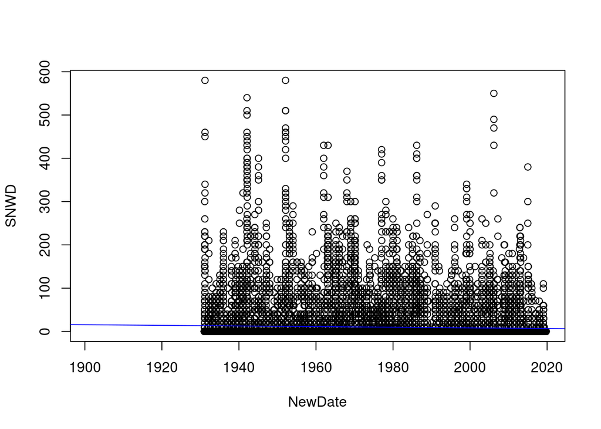

## Possible Solution

Although it is easy to get caught up in the problems displayed by this data, such as the fact that minimum temperature is rising during all months, it is necessary to look forward and consider how to improve the situation. While countries, including Switzerland, are conducting significant research on climate change and are implementing policy changes regarding carbon emissions, atmospheric aerosols, climate mitigation, and adapatation, it is also crucial to look at how the internal industries of the country are being affected.

As temperature increases, it would be in the best interest of the country to simply go along with the possibility that their revenue from the ski season will decrease. Thus, it may be useful to open more hiking trails and embrace the influx of summer tourism and non-cold outdoor excursions that will become more available in the future.

## Sources

https://www.stv-fst.ch/sites/default/files/2019-07/STiZ_2018_EN_Web.pdf

https://www.stv-fst.ch/sites/default/files/2019-07/STiZ_2018_EN_Web.pdf